# Bayesian case study

María Ángeles Magro Garrote

24/4/2024

# Case study: Predicting Hazardous Near-Earth Objects

Near-Earth Objects (NEOs) present a significant concern to our planet’s safety. With the potential to cause catastrophic damage upon impact, accurate prediction and tracking of hazardous NEOs are paramount. This case study focuses on developing predictive models to identify and assess the danger posed by hazardous NEOs, employing both frequentist and Bayesian approaches and comparing them.

[figure not shown]

## 1. Dataset preprocessing

### 1.1. Dataset choice

The dataset used in this study is sourced from an open data collection provided by NASA. It encompasses various variables related to asteroid information, including indicators of whether an asteroid is hazardous or not.

```r
data <- read.csv("nasa.csv")

# summary of the data
str(data)
```

```
## 'data.frame':    4687 obs. of  40 variables:
##  $ Neo.Reference.ID            : int  3703080 3723955 2446862 3092506 3514799 3671135 2495323 2153315 2162463 2306383 ...
##  $ Name                        : int  3703080 3723955 2446862 3092506 3514799 3671135 2495323 2153315 2162463 2306383 ...
##  $ Absolute.Magnitude          : num  21.6 21.3 20.3 27.4 21.6 19.6 19.6 19.2 17.8 21.5 ...
##  $ Est.Dia.in.KM.min.          : num  0.1272 0.1461 0.2315 0.0088 0.1272 ...
##  $ Est.Dia.in.KM.max.          : num  0.2845 0.3266 0.5177 0.0197 0.2845 ...
##  $ Est.Dia.in.M.min.           : num  127.2 146.1 231.5 8.8 127.2 ...
##  $ Est.Dia.in.M.max.           : num  284.5 326.6 517.7 19.7 284.5 ...
##  $ Est.Dia.in.Miles.min.       : num  0.07905 0.09076 0.14385 0.00547 0.07905 ...
##  $ Est.Dia.in.Miles.max.       : num  0.1768 0.203 0.3217 0.0122 0.1768 ...
##  $ Est.Dia.in.Feet.min.        : num  417.4 479.2 759.5 28.9 417.4 ...
##  $ Est.Dia.in.Feet.max.        : num  933.3 1071.6 1698.3 64.6 933.3 ...
##  $ Close.Approach.Date         : chr  "1995-01-01" "1995-01-01" "1995-01-08" "1995-01-15" ...
##  $ Epoch.Date.Close.Approach   : num  7.89e+11 7.89e+11 7.90e+11 7.90e+11 7.90e+11 ...
##  $ Relative.Velocity.km.per.sec: num  6.12 18.11 7.59 11.17 9.84 ...
```

[output cut: 26 more lines]

### 1.2.Feature selection

In order to reduce the variable dimension, we may keep only one distance metric.

- Est.Dia.in.KM.min.: Minimum estimated diameter of the NEO in kilometers.
- Est.Dia.in.KM.max.: Maximum estimated diameter of the NEO in kilometers.
- Est.Dia.in.M.min.: Minimum estimated diameter of the NEO in meters.
- Est.Dia.in.M.max.: Maximum estimated diameter of the NEO in meters.
- Est.Dia.in.Miles.min.: Minimum estimated diameter of the NEO in miles.
- Est.Dia.in.Miles.max.: Maximum estimated diameter of the NEO in miles.
- Est.Dia.in.Feet.min.: Minimum estimated diameter of the NEO in feet.
- Est.Dia.in.Feet.max.: Maximum estimated diameter of the NEO in feet.

```r
# Creation of Est.Dia.in.M.Avg
data$Est.Dia.in.M.Avg <- (data$Est.Dia.in.M.min. + data$Est.Dia.in.M.max.) / 2
```

- Relative.Velocity.km.per.sec: Relative velocity of the NEO with respect to Earth in kilometers per second.
- Relative.Velocity.km.per.hr: Relative velocity of the NEO with respect to Earth in kilometers per hour.
- Miles.per.hour: Relative velocity of the NEO with respect to Earth in miles per hour.

**Relative.Velocity.km.per.hr will be keeped**

- Miss.Dist..Astronomical.: Miss distance of the NEO from Earth in astronomical units.
- Miss.Dist..lunar.: Miss distance of the NEO from Earth in lunar distances.
- Miss.Dist..kilometers.: Miss distance of the NEO from Earth in kilometers.
- Miss.Dist..miles.: Miss distance of the NEO from Earth in miles.

**Miss.Dist..kilometers will be keeped**

Furthermore, the IDs, names and dates variables will be erased because they do not provided any useful information for detecting if the NEO is hazardous.

```r
# Eliminating the other metrics variables and name, IDs, and dates
data <- subset(data, select = -c(Est.Dia.in.KM.min., Est.Dia.in.KM.max., Est.Dia.in.M.max., Est.Dia.in.M.min., Est.Dia.in.Miles.min., Est.Dia.in.Miles.max., Est.Dia.in.Feet.min., Est.Dia.in.Feet.max., Relative.Velocity.km.per.sec, Miles.per.hour, Miss.Dist..Astronomical., Miss.Dist..lunar.,Miss.Dist..miles., Neo.Reference.ID, Name, Orbit.ID, Close.Approach.Date, Epoch.Date.Close.Approach, Orbit.Determination.Date, Epoch.Osculation ))
```

The next step in order to achieve a better reduction of the dimensionality of our dataset could be checking the correlation among numerical ones.

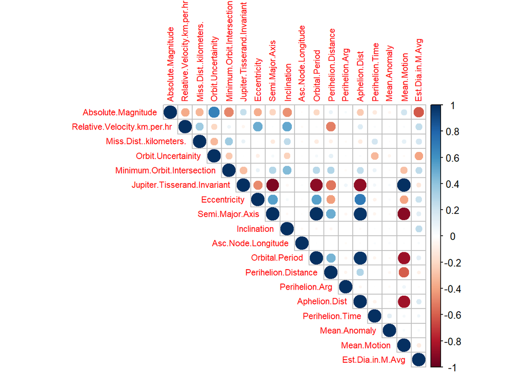

```r
# Select numerical variables
numerical_data <- data[, sapply(data, is.numeric)]

# Compute correlation matrix
correlation_matrix <- cor(numerical_data)

# Create correlation plot
corrplot(correlation_matrix, method = "circle", type = "upper", tl.cex = 0.7)
```

Removing some variables to avoid redundancy and colinearity.

```r
# absolute magnitude & estimated diameter (redundancy)
data <- subset(data, select = -c(Est.Dia.in.M.Avg))

# avoiding colinearity
data <- subset(data, select = -c(Mean.Motion))
data <- subset(data, select = -c(Orbital.Period))
data <- subset(data, select = -c(Aphelion.Dist))
```

There are some variables which only have one level and, therefore, they do not provide any information.

```r
unique(data$Orbiting.Body)
```

```
## [1] "Earth"
```

```r
unique(data$Equinox)
```

```
## [1] "J2000"
```

```r
data <- subset(data, select = -c(Orbiting.Body, Equinox))
```

Let’s review our dataset again after this initial cleaning.

```r
str(data)
```

```
## 'data.frame':    4687 obs. of  15 variables:
##  $ Absolute.Magnitude         : num  21.6 21.3 20.3 27.4 21.6 19.6 19.6 19.2 17.8 21.5 ...
##  $ Relative.Velocity.km.per.hr: num  22017 65210 27327 40226 35427 ...
##  $ Miss.Dist..kilometers.     : num  62753692 57298148 7622912 42683616 61010824 ...
##  $ Orbit.Uncertainity         : int  5 3 0 6 1 1 1 0 0 0 ...
##  $ Minimum.Orbit.Intersection : num  0.02528 0.18693 0.04306 0.00551 0.0348 ...
##  $ Jupiter.Tisserand.Invariant: num  4.63 5.46 4.56 5.09 5.15 ...
##  $ Eccentricity               : num  0.426 0.352 0.348 0.217 0.21 ...
##  $ Semi.Major.Axis            : num  1.41 1.11 1.46 1.26 1.23 ...
##  $ Inclination                : num  6.03 28.41 4.24 7.91 16.79 ...
##  $ Asc.Node.Longitude         : num  314.4 136.7 259.5 57.2 84.6 ...
##  $ Perihelion.Distance        : num  0.808 0.718 0.951 0.984 0.968 ...
##  $ Perihelion.Arg             : num  57.3 313.1 248.4 18.7 158.3 ...
##  $ Perihelion.Time            : num  2458162 2457795 2458120 2457902 2457814 ...
##  $ Mean.Anomaly               : num  264.8 173.7 292.9 68.7 135.1 ...
##  $ Hazardous                  : chr  "True" "False" "True" "False" ...
```

To ascertain the necessity of removing variables, the correlation between each variable and the target will be computed. Only variables demonstrating a discernible correlation will be retained for further analysis.

```r
# Convert 'Hazardous' to binary numeric variable
data$Hazardous <- as.numeric(data$Hazardous == "True")

# Calculate correlation
correlation <- cor(data[, -c(15)], data$Hazardous)

# Display sorted correlation values
print(correlation)
```

```
##                                     [,1]
## Absolute.Magnitude          -0.325521929
## Relative.Velocity.km.per.hr  0.191970180
## Miss.Dist..kilometers.       0.032407426
## Orbit.Uncertainity          -0.328721343
## Minimum.Orbit.Intersection  -0.288949021
## Jupiter.Tisserand.Invariant -0.003403937
## Eccentricity                 0.183269132
## Semi.Major.Axis             -0.010770279
## Inclination                  0.009606872
## Asc.Node.Longitude           0.017536477
## Perihelion.Distance         -0.207026928
## Perihelion.Arg              -0.003865209
## Perihelion.Time              0.038113360
## Mean.Anomaly                 0.054163635
```

Therefore, the chosen variables for the model construction are:

```r
data <- subset(data, select = c(Absolute.Magnitude, Relative.Velocity.km.per.hr, Orbit.Uncertainity, Minimum.Orbit.Intersection, Perihelion.Distance, Eccentricity, Hazardous))
```

### 1.3. Data cleaning and transformation

First, missing values must be checked out.

```r
missing_values <- sum(is.na(data))
missing_values
```

```
## [1] 0
```

Next, an assessment will be conducted to identify any imbalances within our predicted variable, “Hazardous.”

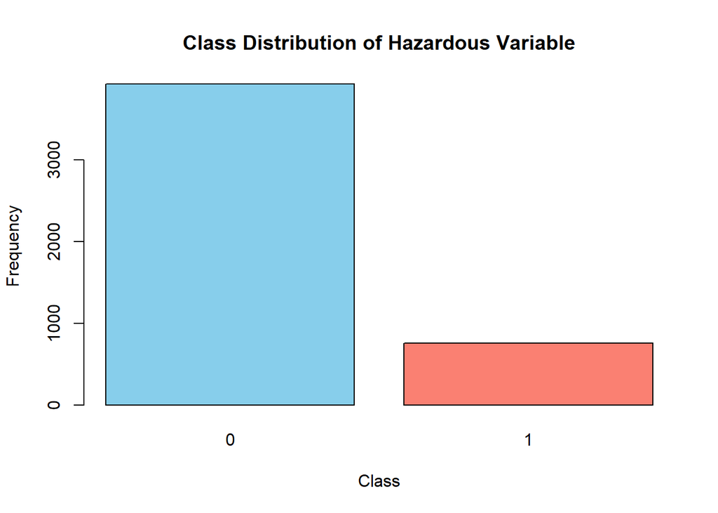

```r
class_distribution <- table(data$Hazardous)

barplot(class_distribution, main = "Class Distribution of Hazardous Variable",
        xlab = "Class", ylab = "Frequency", col = c("skyblue", "salmon"))
```

In order to address the imbalance, the minority class is oversampled by randomly selecting instances from it to match the count of the majority class. This oversampled subset of data is then combined with the original dataset to create a balanced dataset where both classes are equally represented. This ensures that any model is not biased towards the majority class, thereby enhancing its performance in handling imbalanced data.

```r
# Check current class distribution
class_distribution <- table(data$Hazardous)
print(class_distribution)
```

```
##
##    0    1
## 3932  755
```

```r
# Calculate the maximum count among classes
max_count <- max(class_distribution)

# Identify minority and majority classes
minority_class <- names(class_distribution)[which.min(class_distribution)]
majority_class <- names(class_distribution)[which.max(class_distribution)]

# Oversample the minority class
minority_indices <- which(data$Hazardous == minority_class)
oversampled_indices <- sample(minority_indices, max_count - class_distribution[minority_class], replace = TRUE)
oversampled_data <- data[oversampled_indices, ]

# Combine oversampled data with original data
balanced_data <- rbind(data, oversampled_data)

# Check the new class distribution
balanced_class_distribution <- table(balanced_data$Hazardous)
print(balanced_class_distribution)
```

```
##
##    0    1
## 3932 3932
```

```r
# the new data will be the balanced data
data <- balanced_data
```

### 1.4. Variable exploration & visualization

First, it can be a good idea to plot the density of our numerical variables.

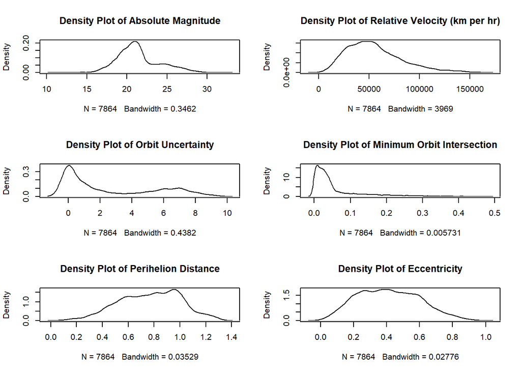

```r
# Set the layout to arrange plots in a grid
par(mfrow = c(3, 2))  # 3 rows, 2 columns

# Create density plots for each variable
plot(density(data$Absolute.Magnitude), main = "Density Plot of Absolute Magnitude")
plot(density(data$Relative.Velocity.km.per.hr), main = "Density Plot of Relative Velocity (km per hr)")
plot(density(data$Orbit.Uncertainity), main = "Density Plot of Orbit Uncertainty")
plot(density(data$Minimum.Orbit.Intersection), main = "Density Plot of Minimum Orbit Intersection")
plot(density(data$Perihelion.Distance), main = "Density Plot of Perihelion Distance")
plot(density(data$Eccentricity), main = "Density Plot of Eccentricity")
```

Now, it could provide us useful insights dividing this densities by Hazardous.

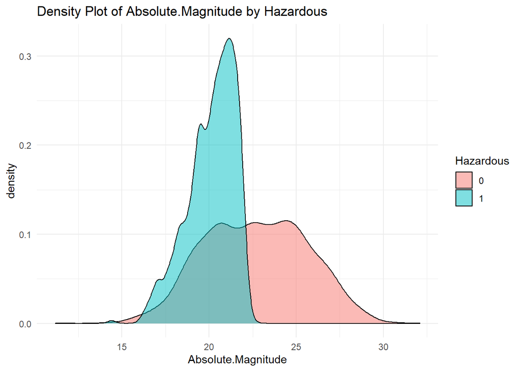

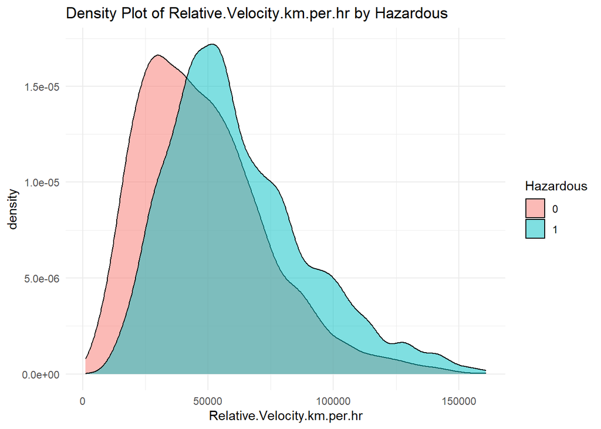

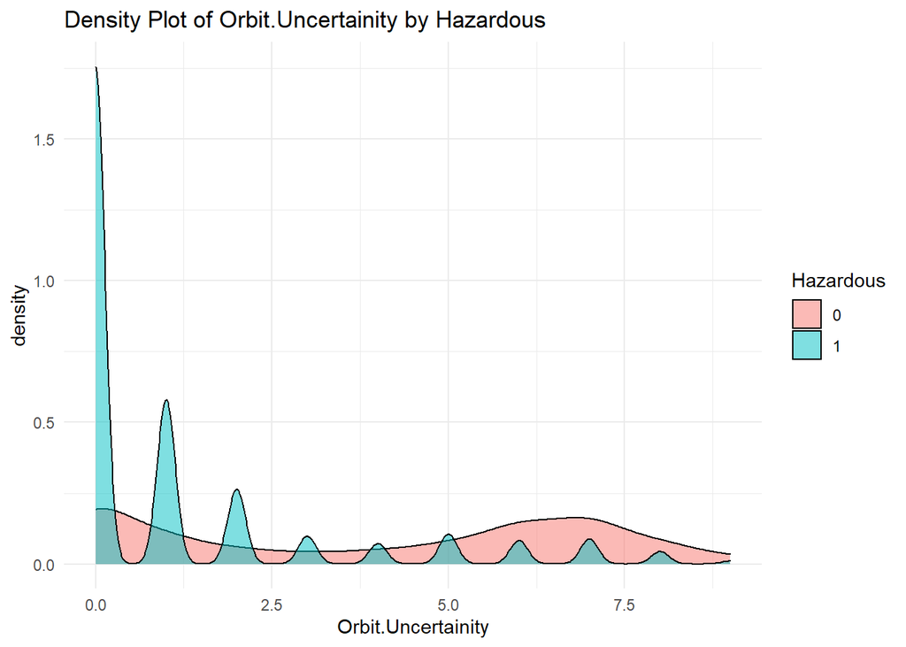

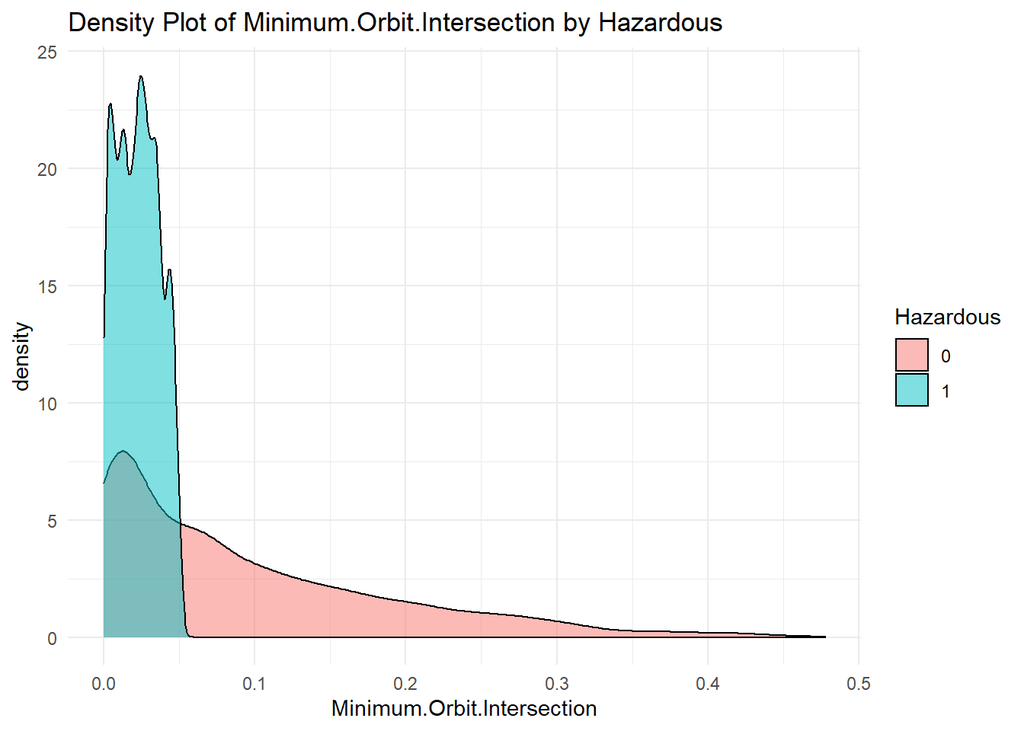

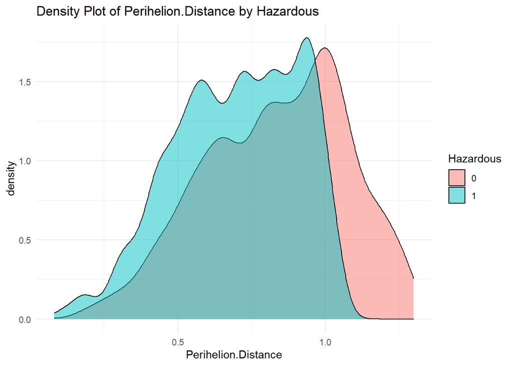

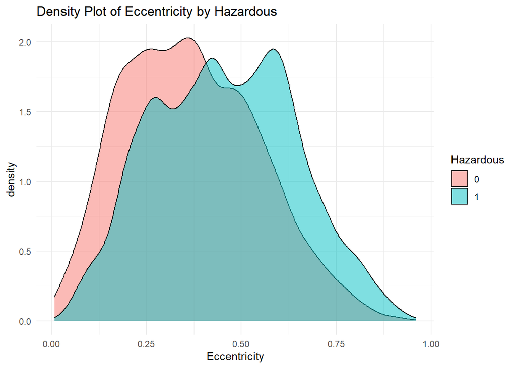

```r
# Get the column names excluding 'Hazardous'
plot_vars <- setdiff(names(data), "Hazardous")

# Create density plots for each variable in plot_vars
density_plots <- lapply(plot_vars, function(var) {
  ggplot(data, aes(x = !!as.name(var), fill = as.factor(Hazardous))) +
    geom_density(alpha = 0.5) +
    labs(title = paste("Density Plot of", var, "by Hazardous"), x = var, fill = "Hazardous") +
    theme_minimal()
})

# Print the plots
print(density_plots)
```

Also some interesting views can be extracted from plotting the boxplots of the numerical variables divided by Hazardous.

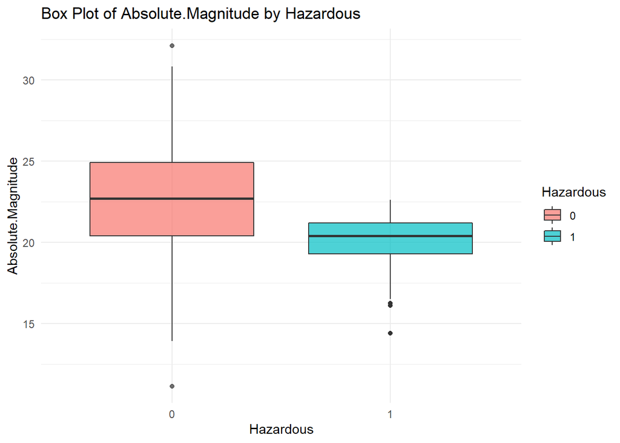

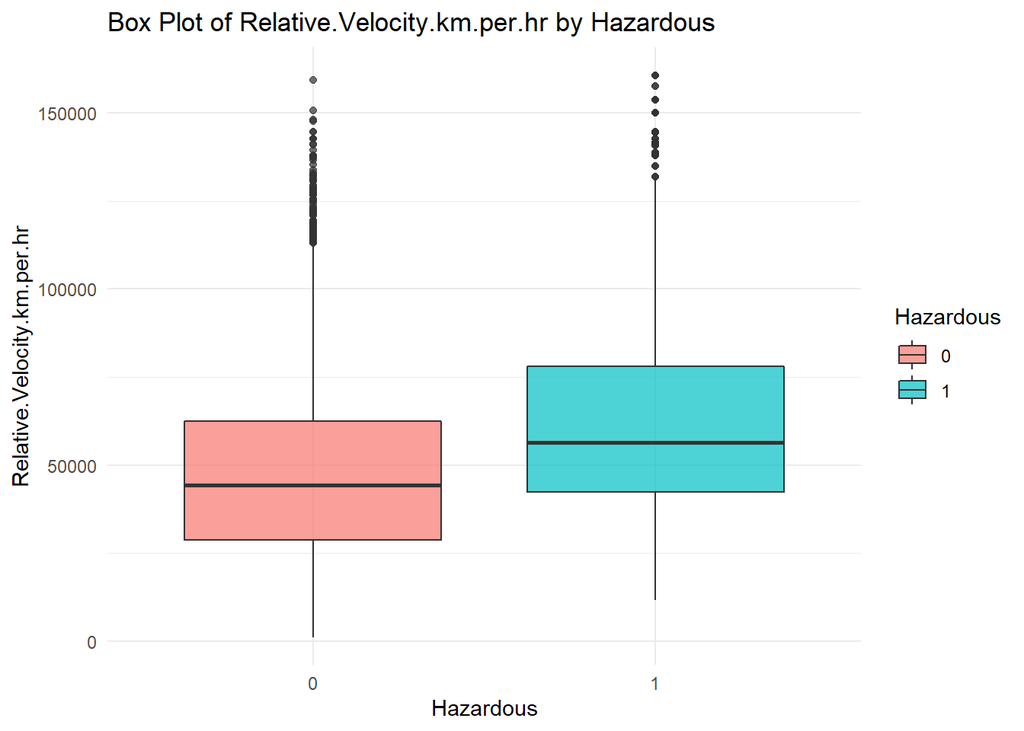

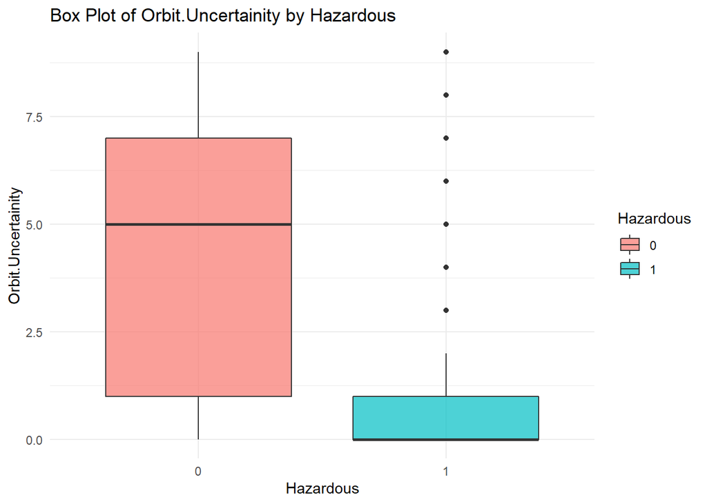

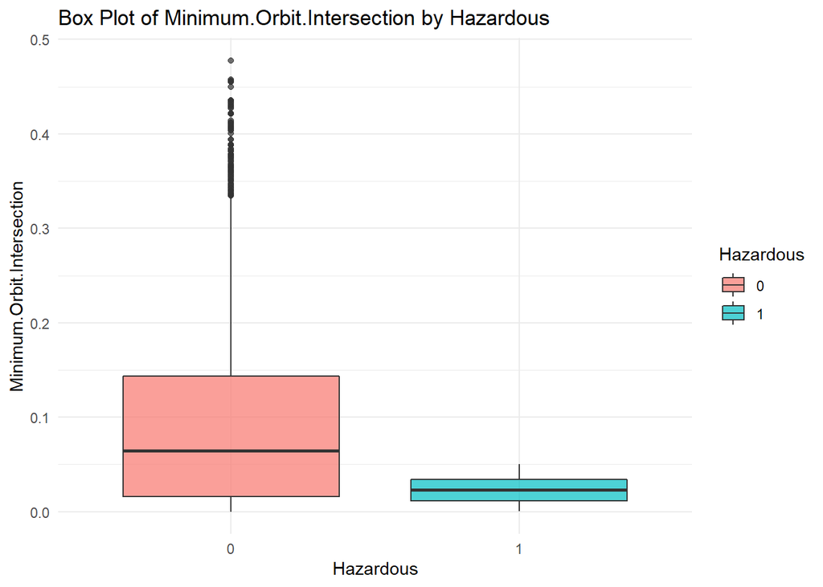

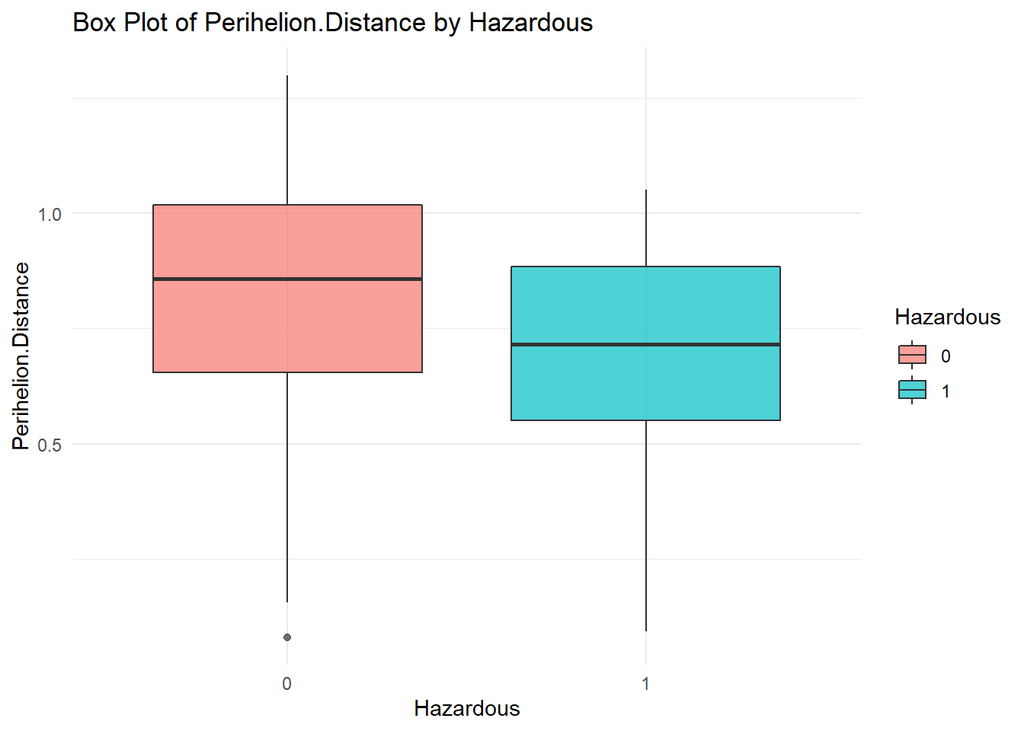

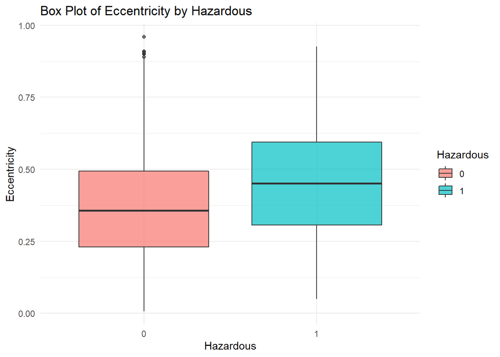

```r
# Get the column names excluding 'Hazardous'
plot_vars <- setdiff(names(data), "Hazardous")

# Create box plots for each variable in plot_vars
box_plots <- lapply(plot_vars, function(var) {
  ggplot(data, aes(x = as.factor(Hazardous), y = !!as.name(var), fill = as.factor(Hazardous))) +
    geom_boxplot(alpha = 0.7) +
    labs(title = paste("Box Plot of", var, "by Hazardous"), x = "Hazardous", y = var, fill = "Hazardous") +
    theme_minimal()
})

# Print the plots
print(box_plots)
```

### 1.5. Creation of a training and test set

To evaluate the accuracy of the models, a subset will be created for training purposes, and another for testing.

```r
# Set seed for reproducibility
set.seed(123)

# Split the dataset into 80% training and 20% testing
train_index <- createDataPartition(data$Hazardous, p = 0.8, list = FALSE)
train_data <- data[train_index, ]
test_data <- data[-train_index, ]
```

## 2. Frequentist model

In frequentist statistics, probabilities represent long-run frequencies or limits of certain events occurring, based on repeated sampling. It treats parameters as fixed but unknown values, estimating them through methods like maximum likelihood estimation.

### 2.1. Frequentist model creation

The following code fits a logistic regression model with regularization using the glmnet package, where predictors are provided as a matrix and the target variable is specified as binary.

```r
# Fit logistic regression model with regularization
model <- glmnet(as.matrix(train_data[, -7]), train_data$Hazardous, family = "binomial")
```

### 2.2. Frequentist output

```r
# Assuming you've extracted the coefficients from your model
coefficients <- coef(model)

# Convert the coefficients into a matrix
coefficients_matrix <- as.matrix(coefficients)

# Calculate mean, median, and quantiles for each coefficient
mean_coefficients <- apply(coefficients_matrix, 1, mean)
median_coefficients <- apply(coefficients_matrix, 1, median)
# Calculate 95% confidence interval (2.5th and 97.5th percentiles) for each coefficient
conf_interval <- apply(coefficients_matrix, 1, quantile, probs = c(0.025, 0.975))

# Combine the results into a data frame
coefficients_summary <- data.frame(
  Coefficient = rownames(coefficients_matrix),
  Mean = mean_coefficients,
  Median = median_coefficients,
  Lower_CI = conf_interval[1, ],
  Upper_CI = conf_interval[2, ]
)

# Print the summary
print(coefficients_summary)
```

```
##                                             Coefficient          Mean
## (Intercept)                                 (Intercept)  2.279234e+01
## Absolute.Magnitude                   Absolute.Magnitude -9.462342e-01
## Relative.Velocity.km.per.hr Relative.Velocity.km.per.hr  2.068344e-07
## Orbit.Uncertainity                   Orbit.Uncertainity -1.314317e-01
## Minimum.Orbit.Intersection   Minimum.Orbit.Intersection -6.367872e+01
## Perihelion.Distance                 Perihelion.Distance  3.932759e-01
## Eccentricity                               Eccentricity  3.019048e-01
##                                  Median     Lower_CI      Upper_CI
## (Intercept)                  25.8401363    1.7362470  3.560891e+01
## Absolute.Magnitude           -1.0542516   -1.4997901 -7.543241e-02
## Relative.Velocity.km.per.hr   0.0000000    0.0000000  9.578971e-07
## Orbit.Uncertainity           -0.1417025   -0.2040682  0.000000e+00
## Minimum.Orbit.Intersection  -69.8584731 -110.6794420 -2.099686e+00
## Perihelion.Distance           0.0000000    0.0000000  1.268211e+00
## Eccentricity                  0.0000000    0.0000000  9.322977e-01
```

The results of the regression analysis reveal insightful relationships between predictor variables and the outcome.

Notably, the coefficient for “Absolute Magnitude” suggests a negative impact on the outcome, indicating that as the absolute magnitude increases, there’s a corresponding decrease in the outcome variable. Similarly, the coefficient for “Orbit Uncertainty” indicates a negative influence, suggesting that higher uncertainty in the orbit is associated with a decrease in the outcome.

Conversely, variables like “Perihelion Distance” and “Eccentricity” exhibit positive coefficients, suggesting that an increase in these parameters is associated with a higher outcome value. Confidence intervals provide additional context, indicating the range within which the true coefficients are likely to fall.

These findings offer valuable insights into the factors influencing the outcome variable.

### 2.3. Frequentist prediction

Using the test data, a new column will be created where the frequentist predictions are stored for further analysis. Also, the accuracy can be obtain with the Hazardous labels.

```r
# Predict using the logistic regression model
predicted_probs <- predict(model, newx = as.matrix(test_data[, -7]), type = "response")

# Convert predicted probabilities to binary predictions (0 or 1) based on a threshold (e.g., 0.5)
predicted_class <- ifelse(predicted_probs > 0.5, 1, 0)

# Add the predicted values to the test set
test_data$Freq_Pred <- predicted_class
```

```r
# Compute accuracy
frequentist_accuracy <- mean(test_data$Freq_Pred == test_data$Hazardous)
print(frequentist_accuracy)
```

```
## [1] 0.9210122
```

The same as before can be done with new data by structuring it into a dataset.

```r
# Create hypothetical data with the correct variables
hypothetical_data <- data.frame(
  Absolute.Magnitude = c(20.5, 18.2, 22.0),
  Relative.Velocity.km.per.hr = c(15000, 25000, 10000),
  Orbit.Uncertainity = c(0.1, 0.5, 0.8),
  Minimum.Orbit.Intersection = c(0.05, 0.1, 0.15),
  Perihelion.Distance = c(0.8, 0.9, 1.0),
  Eccentricity = c(0.2, 0.3, 0.4)
)

# Convert hypothetical data to matrix format
hypothetical_data_matrix <- as.matrix(hypothetical_data)

# Predict probabilities of being hazardous without regularization
predictions_no_regularization <- predict(model, newx = hypothetical_data_matrix, type = "response", s = 0)

# Thresholding the predicted probabilities
frequentist_predictions <- ifelse(predictions_no_regularization > 0.5, 1, 0)

# Print binary predictions
print(frequentist_predictions)
```

```
##      s1
## [1,]  1
## [2,]  0
## [3,]  0
```

## 3. Bayesian model (R2OpenBUGS)

Bayesian statistics views probabilities as measures of uncertainty or degrees of belief, updating prior beliefs with observed data to obtain posterior distributions. It incorporates prior information about parameters and provides a framework for making probabilistic statements about them, accounting for uncertainty in a more explicit manner.

### 3.1. R2OpenBUGS model creation

R2OpenBUGS serves as a bridge between the statistical computing environment in R and OpenBUGS, facilitating the creation, manipulation, and analysis of Bayesian models. This interface allows R users to harness the powerful Bayesian modeling capabilities of OpenBUGS while leveraging the extensive data manipulation and visualization tools available in R.

```r
# Number of observations
n <- nrow(train_data)

# Bayesian logistic model for classification
model <- function(){
  for( i in 1:n){
    # Logistic!
    y[i] ~ dbern(p[i])
    logit(p[i]) <- beta0 + beta1 * x1[i] + beta2 * x2[i] + beta3 * x3[i] + beta4 * x4[i] + beta5 * x5[i] + beta6 * x6[i]
  }

  beta0 ~ dnorm(0.0, 1.0E-6)
  beta1 ~ dnorm(0.0, 1.0E-6)
  beta2 ~ dnorm(0.0, 1.0E-6)
  beta3 ~ dnorm(0.0, 1.0E-6)
  beta4 ~ dnorm(0.0, 1.0E-6)
  beta5 ~ dnorm(0.0, 1.0E-6)
  beta6 ~ dnorm(0.0, 1.0E-6)
}

# Data list
data_list <- list(
  n = n,
  y = train_data$Hazardous,
  x1 = train_data$Absolute.Magnitude,
  x2 = train_data$Relative.Velocity.km.per.hr,
  x3 = train_data$Orbit.Uncertainity,
  x4 = train_data$Minimum.Orbit.Intersection,
  x5 = train_data$Perihelion.Distance,
  x6 = train_data$Eccentricity
)

# Initial values for parameters
inits <- function(){
  list(beta0 = 0, beta1 = 0, beta2 = 0, beta3 = 0, beta4 = 0, beta5 = 0, beta6 = 0)
}

# Perform Bayesian inference using OpenBUGS
output <- bugs(data = data_list,
               inits = inits,
               parameters.to.save = c("beta0", "beta1", "beta2", "beta3", "beta4", "beta5", "beta6"),
               model.file = model,
               n.chains = 1,
               n.burnin = 500,
               n.iter = 5000
)
```

### 3.2. R2OpenBUGS convergence

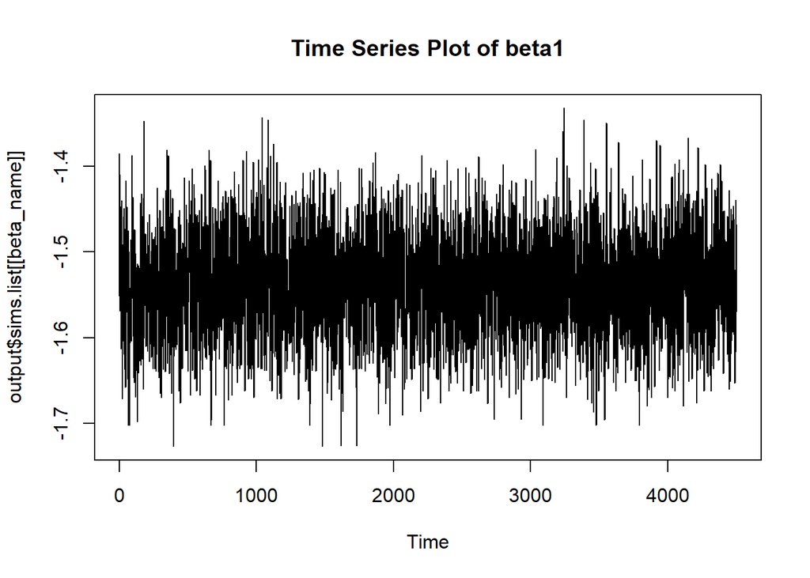

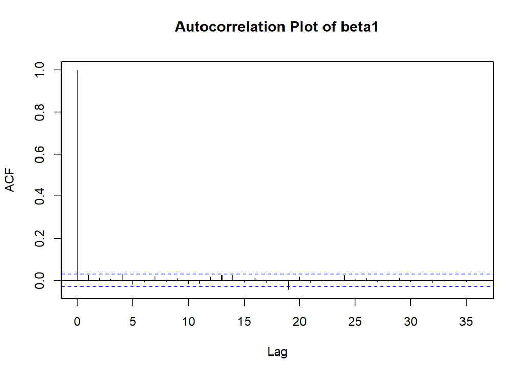

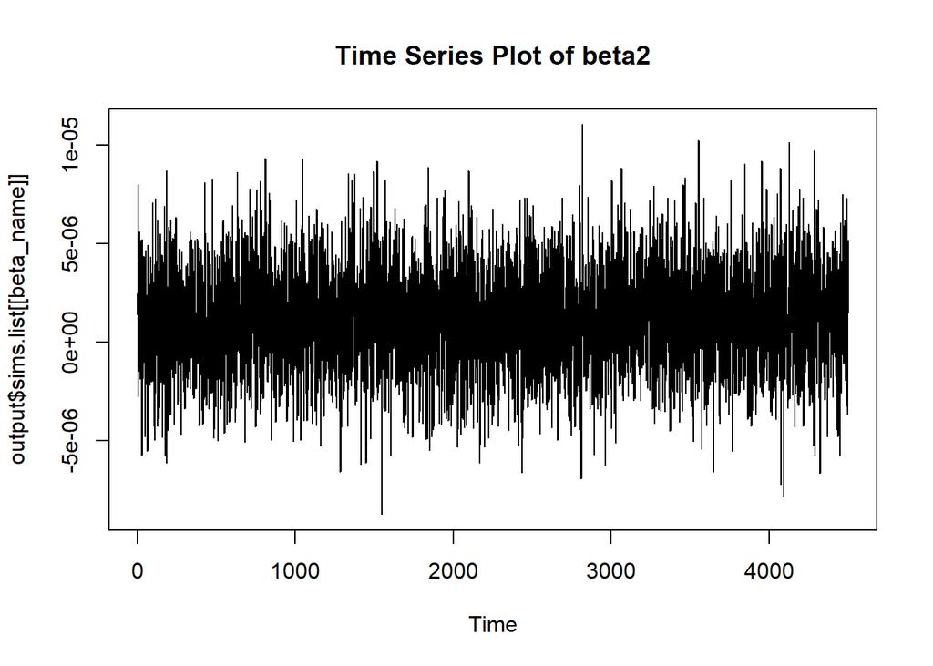

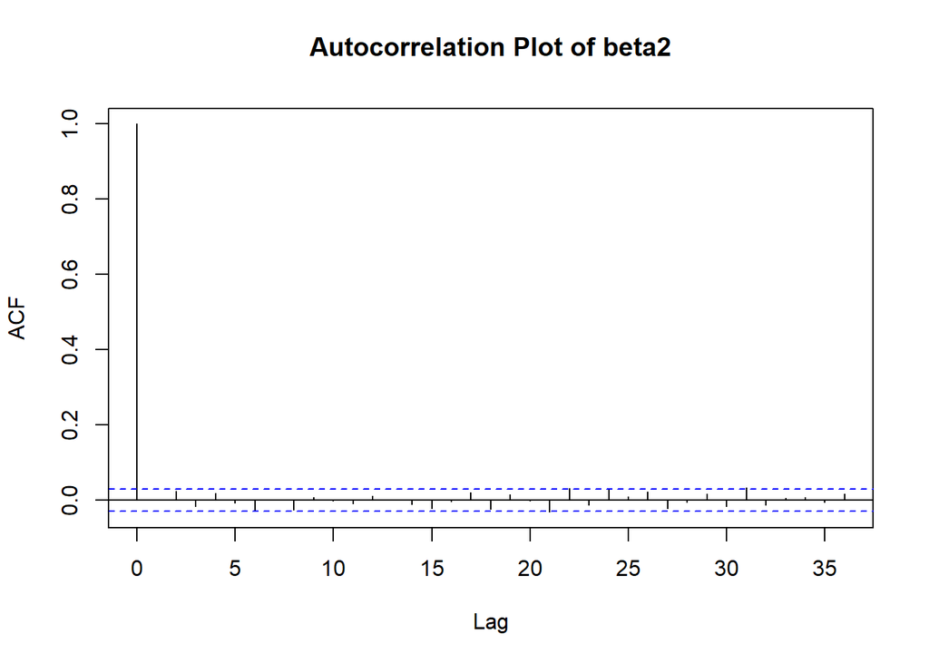

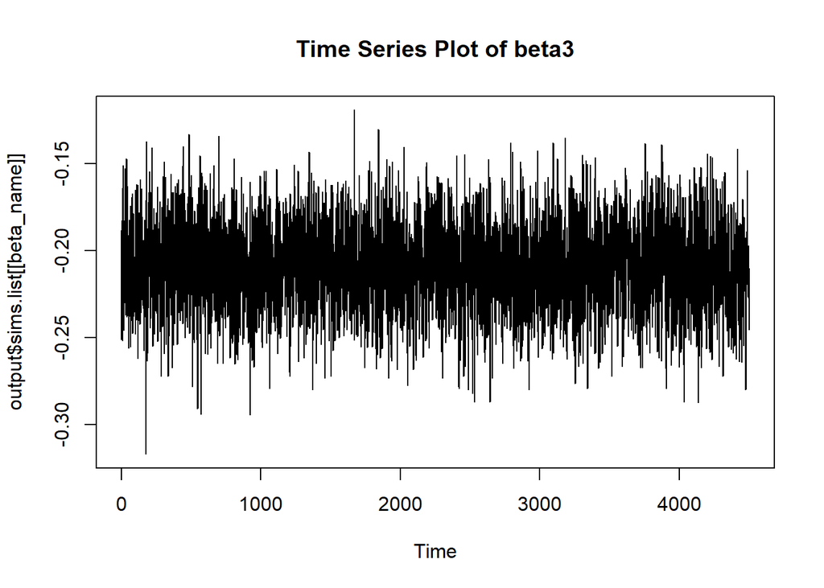

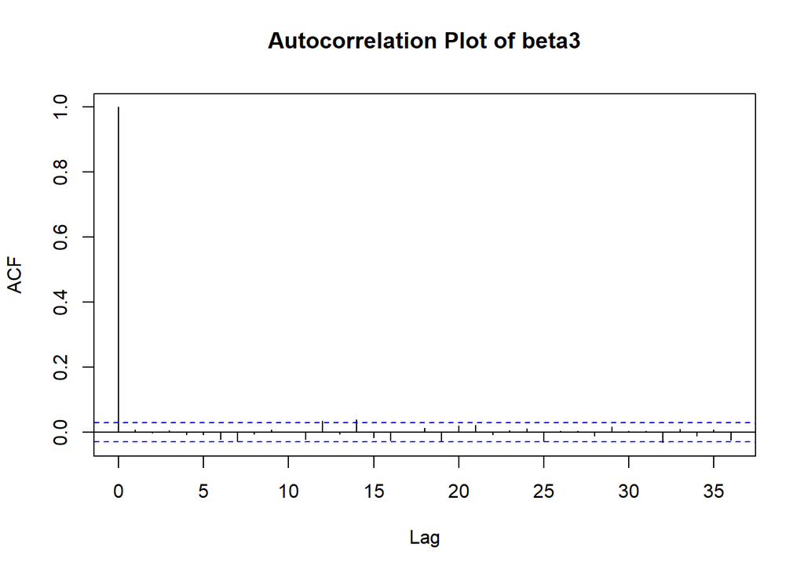

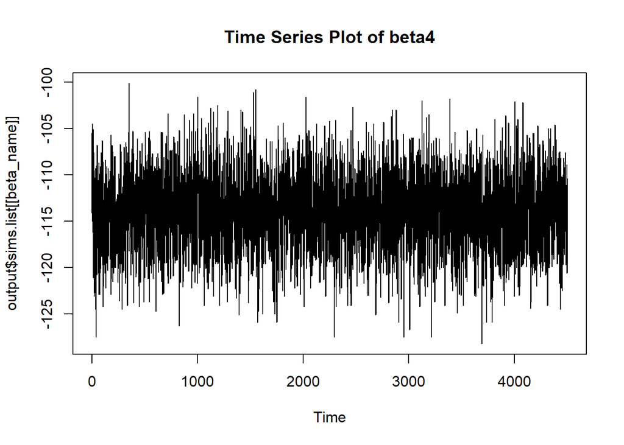

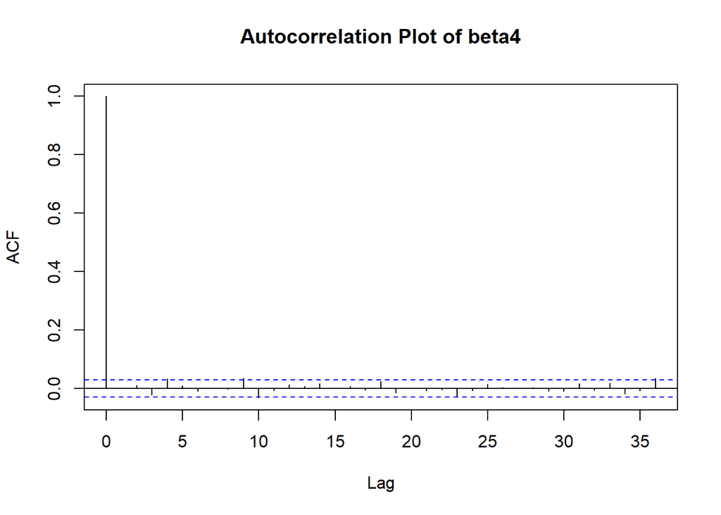

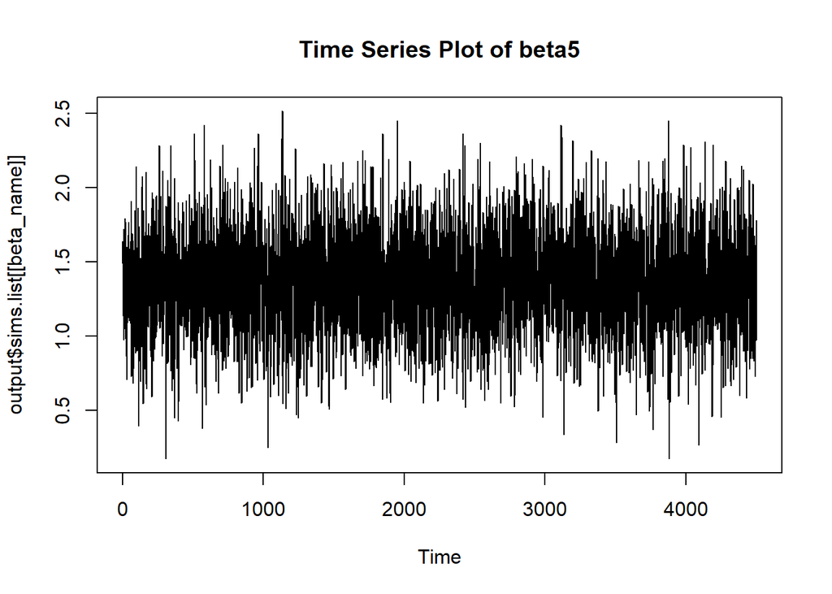

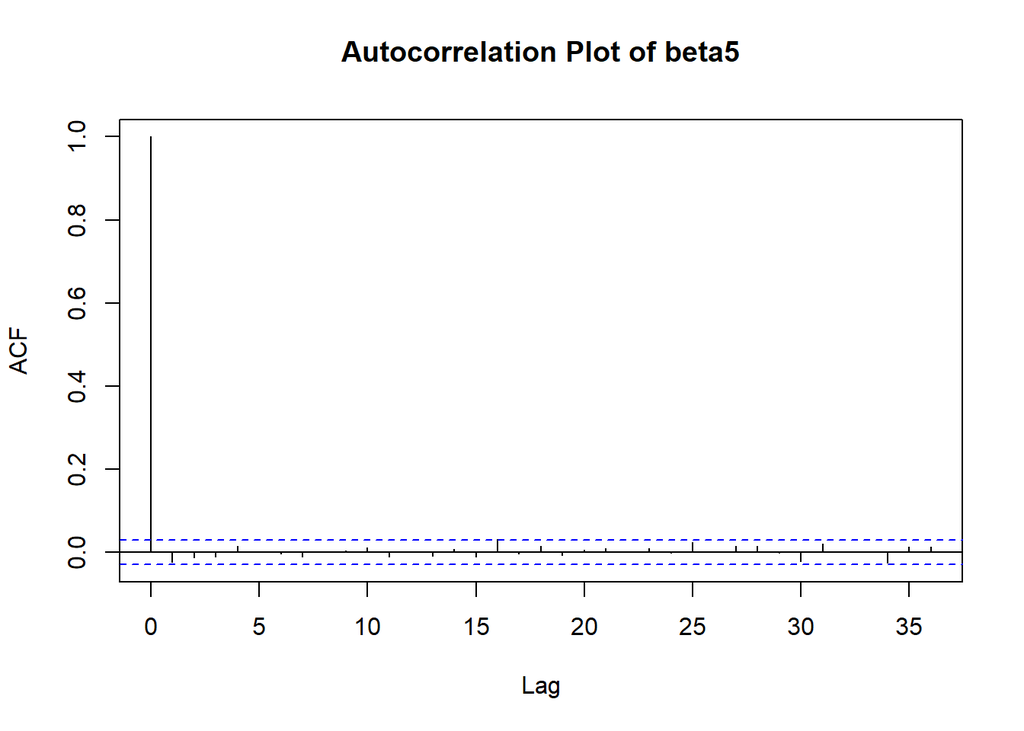

```r
# Iterate over each beta variable from beta1 to beta5
for (i in 1:5) {
  beta_name <- paste0("beta", i)

  # Time series plot for the current beta variable
  ts.plot(output$sims.list[[beta_name]], main = paste("Time Series Plot of", beta_name))

  # Autocorrelation plot for the current beta variable
  acf(output$sims.list[[beta_name]], main = paste("Autocorrelation Plot of", beta_name))
}
```

### 3.3 R2OpenBUGS output

Mean, median and quantiles

```r
# Extract posterior samples
posterior_samples <- output$sims.matrix

# Calculate mean for each parameter
means <- colMeans(posterior_samples)

# Calculate median for each parameter
medians <- apply(posterior_samples, 2, median)

print(means)
```

```
##         beta0         beta1         beta2         beta3         beta4
##  3.644056e+01 -1.537675e+00  1.150455e-06 -2.087688e-01 -1.139769e+02
##         beta5         beta6      deviance
##  1.369335e+00  9.890031e-01  2.107905e+03
```

```r
print(medians)
```

```
##       beta0       beta1       beta2       beta3       beta4       beta5
##  3.6480e+01 -1.5390e+00  1.1130e-06 -2.0840e-01 -1.1380e+02  1.3655e+00
##       beta6    deviance
##  9.9225e-01  2.1070e+03
```

```r
print("Quantiles: ")
```

```
## [1] "Quantiles: "
```

```r
output$summary[, c("2.5%", "97.5%")]
```

```
##                   2.5%         97.5%
## beta0     3.352000e+01  3.920525e+01
## beta1    -1.649000e+00 -1.422000e+00
## beta2    -4.055000e-06  6.168625e-06
## beta3    -2.588000e-01 -1.598475e-01
## beta4    -1.220000e+02 -1.061000e+02
## beta5     7.165375e-01  2.013148e+00
## beta6     1.629050e-01  1.810000e+00
## deviance  2.103000e+03  2.117000e+03
```

In the context of our Bayesian logistic regression analysis, the presented quantiles offer valuable insights into the estimated coefficients and model fit.

These insights aid in understanding the relative importance of predictor variables in influencing the outcome and highlight the uncertainty inherent in the model’s estimation process.

### 2.4. R2OpenBUGS prediction

Again, the test set is predicted with our actual model and a new column is created with these predictions.

```r
# Extract posterior samples
posterior_samples <- as.matrix(output$sims.matrix)

# Define a function to compute predicted probabilities
compute_probs <- function(posterior_samples, x_data) {
  n_samples <- nrow(posterior_samples)
  n_data <- nrow(x_data)
  probs <- matrix(NA, nrow = n_data, ncol = n_samples)
  for (i in 1:n_samples) {
    beta <- posterior_samples[i, ]
    probs[, i] <- plogis(beta[1] +
                         beta[2] * x_data$Absolute.Magnitude +
                         beta[3] * x_data$Relative.Velocity.km.per.hr +
                         beta[4] * x_data$Orbit.Uncertainity +
                         beta[5] * x_data$Minimum.Orbit.Intersection +
                         beta[6] * x_data$Perihelion.Distance +
                         beta[7] * x_data$Eccentricity)
  }
  return(probs)
}

# Compute predicted probabilities for the test set
test_probs <- compute_probs(posterior_samples, test_data)

# Take the mean of the predicted probabilities as the predicted probability
test_predicted_prob <- rowMeans(test_probs)

# Convert probabilities to binary predictions (0 or 1) based on a threshold (0.5)
test_predicted <- ifelse(test_predicted_prob > 0.5, 1, 0)

test_data$R2OpnBugs_Pred <- test_predicted
```

```r
# Compute accuracy over the test set
accuracy_r2openbugs <- mean(test_predicted == test_data$Hazardous)
print(paste("Accuracy:", accuracy_r2openbugs))
```

```
## [1] "Accuracy: 0.926844783715013"
```

Also, using the hypothetical data created before, the prediction is made.

```r
# Compute predicted probabilities for the hypothetical data
hypothetical_probs <- compute_probs(posterior_samples, hypothetical_data)

# Take the mean of the predicted probabilities as the predicted probability
hypothetical_predicted_prob <- rowMeans(hypothetical_probs)

# Convert probabilities to binary predictions (0 or 1) based on a threshold (0.5)
hypothetical_predicted <- ifelse(hypothetical_predicted_prob > 0.5, 1, 0)

# Compute confidence and predictive intervals
confidence_interval <- apply(hypothetical_probs, 1, function(x) quantile(x, c(0.025, 0.975)))
predictive_interval <- apply(hypothetical_probs, 1, function(x) quantile(x, c(0.025, 0.975)))

print("Predicted Probabilities:")
```

```
## [1] "Predicted Probabilities:"
```

```r
print(hypothetical_predicted_prob)
```

```
## [1] 6.240772e-01 1.859735e-01 2.898255e-06
```

```r
print("Binary Predictions:")
```

```
## [1] "Binary Predictions:"
```

```r
print(hypothetical_predicted)
```

```
## [1] 1 0 0
```

```r
print("Confidence Interval (95%):")
```

```
## [1] "Confidence Interval (95%):"
```

```r
print(confidence_interval)
```

```
##            [,1]      [,2]         [,3]
## 2.5%  0.5622760 0.1295152 9.394033e-07
## 97.5% 0.6814872 0.2500235 6.609689e-06
```

```r
print("Predictive Interval (95%):")
```

```
## [1] "Predictive Interval (95%):"
```

```r
print(predictive_interval)
```

```
##            [,1]      [,2]         [,3]
## 2.5%  0.5622760 0.1295152 9.394033e-07
## 97.5% 0.6814872 0.2500235 6.609689e-06
```

## 4. MCMC

```r
# Define the logistic regression model
bayes_model <- MCMClogit(Hazardous ~ Absolute.Magnitude +
                          Relative.Velocity.km.per.hr +
                          Orbit.Uncertainity +
                          Minimum.Orbit.Intersection +
                          Perihelion.Distance +
                          Eccentricity,
                          data = train_data, thin = 10, burnin = 1000, mcmc = 50000)
# Summary of the MCMC output
summary(bayes_model)
```

```
##
## Iterations = 1001:50991
## Thinning interval = 10
## Number of chains = 1
## Sample size per chain = 5000
##
## 1. Empirical mean and standard deviation for each variable,
##    plus standard error of the mean:
##
##                                   Mean        SD  Naive SE Time-series SE
## (Intercept)                  3.643e+01 1.499e+00 2.120e-02      3.412e-02
## Absolute.Magnitude          -1.537e+00 6.079e-02 8.597e-04      1.371e-03
## Relative.Velocity.km.per.hr  1.145e-06 2.702e-06 3.821e-08      6.001e-08
## Orbit.Uncertainity          -2.085e-01 2.647e-02 3.744e-04      6.086e-04
## Minimum.Orbit.Intersection  -1.140e+02 4.023e+00 5.689e-02      8.853e-02
## Perihelion.Distance          1.369e+00 3.402e-01 4.811e-03      7.457e-03
## Eccentricity                 9.816e-01 4.177e-01 5.907e-03      9.662e-03
##
## 2. Quantiles for each variable:
##
##                                   2.5%        25%        50%        75%
## (Intercept)                  3.357e+01  3.542e+01  3.642e+01  3.743e+01
## Absolute.Magnitude          -1.658e+00 -1.579e+00 -1.536e+00 -1.496e+00
## Relative.Velocity.km.per.hr -4.269e-06 -6.594e-07  1.139e-06  2.982e-06
## Orbit.Uncertainity          -2.598e-01 -2.264e-01 -2.084e-01 -1.905e-01
## Minimum.Orbit.Intersection  -1.218e+02 -1.166e+02 -1.139e+02 -1.113e+02
## Perihelion.Distance          7.101e-01  1.139e+00  1.371e+00  1.595e+00
## Eccentricity                 1.672e-01  6.984e-01  9.842e-01  1.265e+00
##                                  97.5%
## (Intercept)                  3.941e+01
## Absolute.Magnitude          -1.420e+00
## Relative.Velocity.km.per.hr  6.450e-06
## Orbit.Uncertainity          -1.573e-01
## Minimum.Orbit.Intersection  -1.062e+02
## Perihelion.Distance          2.050e+00
## Eccentricity                 1.812e+00
```

### 4.2. MCMC convergence

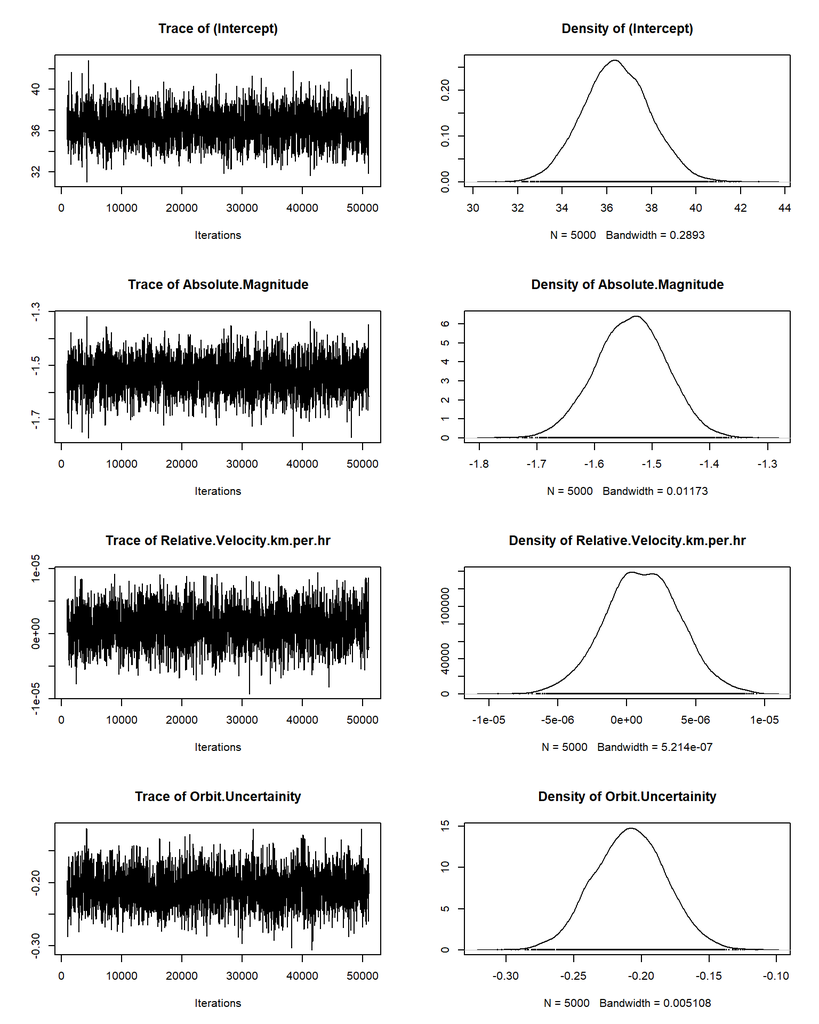

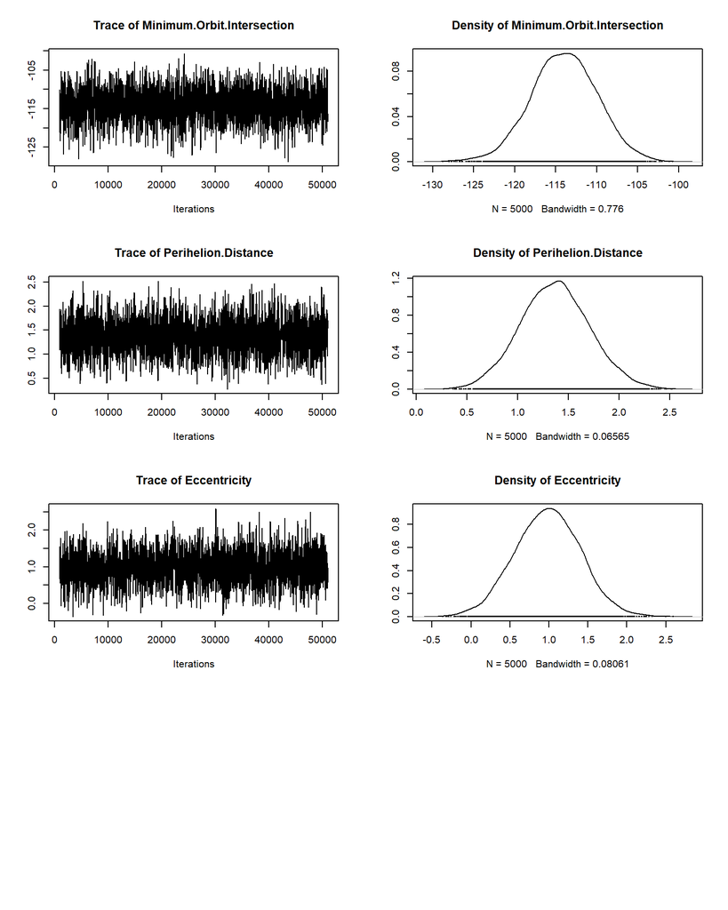

```r
# Plot diagnostics
plot(bayes_model)
```

### 4.3. MCMC output

```r
# Extract coefficients and sigma2
beta <- bayes_model[, 1:6]
sigma2 <- bayes_model[, 7]

# Mean and median of coefficients
apply(beta, 2, mean)
```

```
##                 (Intercept)          Absolute.Magnitude
##                3.643244e+01               -1.537177e+00
## Relative.Velocity.km.per.hr          Orbit.Uncertainity
##                1.145399e-06               -2.085350e-01
##  Minimum.Orbit.Intersection         Perihelion.Distance
##               -1.139826e+02                1.368746e+00
```

```r
apply(beta, 2, median)
```

```
##                 (Intercept)          Absolute.Magnitude
##                3.641848e+01               -1.535503e+00
## Relative.Velocity.km.per.hr          Orbit.Uncertainity
##                1.139108e-06               -2.083577e-01
##  Minimum.Orbit.Intersection         Perihelion.Distance
##               -1.139376e+02                1.371380e+00
```

```r
# Mean and median of sigma2
mean(sigma2)
```

```
## [1] 0.9816075
```

```r
median(sigma2)
```

```
## [1] 0.984153
```

```r
# 95% credible intervals
apply(bayes_model, 2, quantile, probs = c(0.025, 0.975))
```

```
##       (Intercept) Absolute.Magnitude Relative.Velocity.km.per.hr
## 2.5%     33.56653          -1.658118               -4.269036e-06
## 97.5%    39.40512          -1.419835                6.449876e-06
##       Orbit.Uncertainity Minimum.Orbit.Intersection Perihelion.Distance
## 2.5%          -0.2597840                  -121.8341           0.7101432
## 97.5%         -0.1572632                  -106.1876           2.0498238
##       Eccentricity
## 2.5%     0.1671528
## 97.5%    1.8120862
```

This model identified several key predictors.

### 4.4. Data prediction

Again, the predictions can be done to the test set and the accuracy can be obtained.

```r
# Convert bayes_model object to matrix
posterior_samples <- as.matrix(bayes_model)

# Extract the predictor variables from test_data
x_new <- model.matrix(~ Absolute.Magnitude + Relative.Velocity.km.per.hr +
                       Orbit.Uncertainity + Minimum.Orbit.Intersection +
                       Perihelion.Distance + Eccentricity, data = test_data)

# Perform matrix multiplication
predictions <- x_new %*% t(posterior_samples)

# Take the mean of the predictions across all posterior samples
predicted_hazardous <- rowMeans(predictions)

# Classify predictions based on threshold (0.5)
test_data$MCMC_Pred <- ifelse(predicted_hazardous > 0.5, 1, 0)

# Calculate accuracy
mcmc_accuracy <- mean(test_data$MCMC_Pred == as.numeric(test_data$Hazardous))

# Print the accuracy
print(paste("Accuracy:", mcmc_accuracy))
```

```
## [1] "Accuracy: 0.922391857506361"
```

Finally, let’s predict hypotethetical data again with this model.

```r
# Convert bayes_model object to matrix
posterior_samples <- as.matrix(bayes_model)

# Extract the predictor variables from hypothetical_data
x_new <- model.matrix(~ Absolute.Magnitude + Relative.Velocity.km.per.hr +
                       Orbit.Uncertainity + Minimum.Orbit.Intersection +
                       Perihelion.Distance + Eccentricity, data = hypothetical_data)

# Perform matrix multiplication
predictions <- x_new %*% t(posterior_samples)

# Take the mean of the predictions across all posterior samples
predicted_probabilities <- rowMeans(predictions)

# Convert probabilities to binary outcomes (0 or 1) based on threshold (0.5)
predicted_hazardous <- ifelse(predicted_probabilities > 0.5, 1, 0)

# Print the predicted Hazardous output
print(predicted_hazardous)
```

```
## 1 2 3
## 1 0 0
```

## Conclusions

In this project, we developed and compared three different approaches for predicting asteroid hazardousness: frequentist logistic regression, Bayesian logistic regression using R2OpenBUGS, and Bayesian logistic regression using MCMC methods.

```r
print(frequentist_accuracy)
```

```
## [1] 0.9210122
```

```r
print(accuracy_r2openbugs)
```

```
## [1] 0.9268448
```

```r
print(mcmc_accuracy)
```

```
## [1] 0.9223919
```

Starting with frequentist logistic regression, we obtained a lower accuracy than the rest. This method provides point estimates for coefficients and does not explicitly account for uncertainty.

Moving on to Bayesian logistic regression with R2OpenBUGS, we leveraged the power of Bayesian statistics to model uncertainty explicitly. This approach yielded an accuracy similar to MCMC. By sampling from the posterior distribution of parameters, we gained insights into parameter uncertainty and model fit, allowing us to make probabilistic statements about the coefficients.

Finally, we employed MCMC methods for Bayesian logistic regression, which also provided estimates of parameter uncertainty. By summarizing the posterior distributions of coefficients and examining their credible intervals, we gained valuable insights into the relative importance of predictor variables and their associations with asteroid hazardousness.

Comparing the three methods, we found that Bayesian approaches, both with R2OpenBUGS and MCMC, generally outperformed frequentist logistic regression. Additionally, Bayesian methods provided richer insights into parameter uncertainty and model fit, enabling more informed decision-making.

In scrutinizing the model outputs from both R2OpenBUGS and MCMC analyses, it becomes apparent that certain predictor variables exert varying degrees of influence on predicting hazardous space events. Notably, Absolute Magnitude (beta1), Orbit Uncertainty (beta3), Minimum Orbit Intersection (beta4), Perihelion Distance (beta5), and Eccentricity (beta6) consistently emerge as pivotal factors, exhibiting significance as their confidence intervals exclude zero in both analyses. These variables are deemed more critical in forecasting hazardous occurrences in space. Conversely, Relative Velocity (beta2) demonstrates less consistent importance, with its confidence interval encompassing zero, indicating potentially lower relevance in determining the likelihood of hazardous events compared to the others.

This understanding of variable importance underscores the imperative of prioritizing variables with robust and consistent effects for accurate risk assessment and the formulation of effective mitigation strategies in space endeavors.

In conclusion, Bayesian logistic regression, whether implemented through R2OpenBUGS or MCMC methods, offers a powerful framework for modeling uncertainty and making probabilistic predictions about asteroid hazardousness. These approaches can be valuable tools for decision-making in asteroid risk assessment and mitigation efforts.